# 0. Introduction

In this notebook, I will go through my first hands-on machine learning project and that will be from the Kaggle Titanic survival prediction competition. The aim of this competition is simple, to predict weather someone survived or not.

I read somewhere when you want to master any skill or anything, take it from the perspective of a marathon race. This is not a sprint race. I have learned a lot on my marathon as a data scientist and machine learning and I hope you will find value on the note book.

I drew inspirations from the following notebooks in the making of this notebook:

a) Github: https://github.com/chongjason914/kaggle-titanic/blob/main/titanic-tutorial.ipynb

b)kaggle: Titanic Data Set_Final_Trial by Amr.E.Abdelgawad

c)Kaggle: On titanic data set on the kaggle website code sections, you will find some other exciting notebooks and learn a lot

d)link by Peter Begle:https://medium.com/i-like-big-data-and-i-cannot-lie/how-i-scored-in-the-top-9-of-kaggles-titanic-machine-learning-challenge-243b5f45c8e9 . Feel free to check out his note book on kaggle also

Kaggle competitions comprise of a minimum of 3 datasets that you can find and download from the competition webpage. The three datasets are:

.Training set

.Test set

.Sample/ Gender submission

Training set This is the dataset that you will be working on to build your machine learning models to produce the outcome i.e. "The Ground Truth" for each passenger. There are two types of machine learning problems, classification and regression problems. Titanic problem is a good example of a classification problem where the outcome is categorical. In summary we are trying do predict weather someone survived or not and our model needs to be able to predict this outcome

Test set

We will use the Test set to see how well our model preforms on unseen data. Note that the ground truth i.e. survived or did not survive feature has not been provided on this data set. So, this is our work to predict the outcome. We are going to the model we trained on the train data set (for each passenger in the test set) to predict weather or not a person survived the titanic

Sample/ Gender Submission Set

Is an example of format of how our final predictions and submission file should look like

## 1. Importing our Libraries

Here I will import the libraries that I will be using in my notebook. Libraries are essentially extensions to Python that consist of functions that are handy to have when we are performing our analysis.

```python
# Importing the basic libraries that i am going to use.

#Data wrangling
import numpy as np  # for linear ALgebra
import pandas as pd  # for Data procesing

#Data Visualisation
import seaborn as sns
import matplotlib.pyplot as plt


#Machine Learning Models
from sklearn.linear_model import LogisticRegression
from sklearn.svm import SVC, LinearSVC
from sklearn.ensemble import RandomForestClassifier
from sklearn.neighbors import KNeighborsClassifier
from sklearn.naive_bayes import GaussianNB
from sklearn.linear_model import Perceptron
from sklearn.linear_model import SGDClassifier
from sklearn.tree import DecisionTreeClassifier
from sklearn import svm

# Model evaluation
from sklearn.model_selection import cross_val_score

# Hyperparameter tuning
from sklearn.model_selection import GridSearchCV


# Remove warnings
import warnings
warnings.filterwarnings('ignore')
```

# 2. Import and Read out Data sets

```python
# Reading of our files
train_set = pd.read_csv(r"C:\Users\DMONGARE\Desktop\J projects\Titanic Data Set\train.csv")
test_set  = pd.read_csv(r"C:\Users\DMONGARE\Desktop\J projects\Titanic Data Set\test.csv")
ss = pd.read_csv(r"C:\Users\DMONGARE\Desktop\J projects\Titanic Data Set\gender_submission.csv")
```

```python
# Opening our Train data set  file
display(train_set)
```

|  | PassengerId | Survived | Pclass | Name | Sex | Age | SibSp | Parch | Ticket | Fare | Cabin | Embarked |
| --- | --- | --- | --- | --- | --- | --- | --- | --- | --- | --- | --- | --- |
| 0 | 1 | 0 | 3 | Braund, Mr. Owen Harris | male | 22.0 | 1 | 0 | A/5 21171 | 7.2500 | NaN | S |
| 1 | 2 | 1 | 1 | Cumings, Mrs. John Bradley (Florence Briggs Th... | female | 38.0 | 1 | 0 | PC 17599 | 71.2833 | C85 | C |
| 2 | 3 | 1 | 3 | Heikkinen, Miss. Laina | female | 26.0 | 0 | 0 | STON/O2. 3101282 | 7.9250 | NaN | S |
| 3 | 4 | 1 | 1 | Futrelle, Mrs. Jacques Heath (Lily May Peel) | female | 35.0 | 1 | 0 | 113803 | 53.1000 | C123 | S |
| 4 | 5 | 0 | 3 | Allen, Mr. William Henry | male | 35.0 | 0 | 0 | 373450 | 8.0500 | NaN | S |
| ... | ... | ... | ... | ... | ... | ... | ... | ... | ... | ... | ... | ... |
| 886 | 887 | 0 | 2 | Montvila, Rev. Juozas | male | 27.0 | 0 | 0 | 211536 | 13.0000 | NaN | S |
| 887 | 888 | 1 | 1 | Graham, Miss. Margaret Edith | female | 19.0 | 0 | 0 | 112053 | 30.0000 | B42 | S |
| 888 | 889 | 0 | 3 | Johnston, Miss. Catherine Helen "Carrie" | female | NaN | 1 | 2 | W./C. 6607 | 23.4500 | NaN | S |
| 889 | 890 | 1 | 1 | Behr, Mr. Karl Howell | male | 26.0 | 0 | 0 | 111369 | 30.0000 | C148 | C |
| 890 | 891 | 0 | 3 | Dooley, Mr. Patrick | male | 32.0 | 0 | 0 | 370376 | 7.7500 | NaN | Q |

891 rows × 12 columns

```python
# Opening out test Data Set File
display(test_set)
```

|  | PassengerId | Pclass | Name | Sex | Age | SibSp | Parch | Ticket | Fare | Cabin | Embarked |
| --- | --- | --- | --- | --- | --- | --- | --- | --- | --- | --- | --- |
| 0 | 892 | 3 | Kelly, Mr. James | male | 34.5 | 0 | 0 | 330911 | 7.8292 | NaN | Q |
| 1 | 893 | 3 | Wilkes, Mrs. James (Ellen Needs) | female | 47.0 | 1 | 0 | 363272 | 7.0000 | NaN | S |
| 2 | 894 | 2 | Myles, Mr. Thomas Francis | male | 62.0 | 0 | 0 | 240276 | 9.6875 | NaN | Q |
| 3 | 895 | 3 | Wirz, Mr. Albert | male | 27.0 | 0 | 0 | 315154 | 8.6625 | NaN | S |
| 4 | 896 | 3 | Hirvonen, Mrs. Alexander (Helga E Lindqvist) | female | 22.0 | 1 | 1 | 3101298 | 12.2875 | NaN | S |
| ... | ... | ... | ... | ... | ... | ... | ... | ... | ... | ... | ... |
| 413 | 1305 | 3 | Spector, Mr. Woolf | male | NaN | 0 | 0 | A.5. 3236 | 8.0500 | NaN | S |
| 414 | 1306 | 1 | Oliva y Ocana, Dona. Fermina | female | 39.0 | 0 | 0 | PC 17758 | 108.9000 | C105 | C |
| 415 | 1307 | 3 | Saether, Mr. Simon Sivertsen | male | 38.5 | 0 | 0 | SOTON/O.Q. 3101262 | 7.2500 | NaN | S |
| 416 | 1308 | 3 | Ware, Mr. Frederick | male | NaN | 0 | 0 | 359309 | 8.0500 | NaN | S |
| 417 | 1309 | 3 | Peter, Master. Michael J | male | NaN | 1 | 1 | 2668 | 22.3583 | NaN | C |

418 rows × 11 columns

```python
train_set.shape
```

```
(891, 12)
```

```python
test_set.shape
```

```
(418, 11)
```

From the information above we can see that test data set as less columns that train data set. The missing feature is the survived column is missing because its our work to predict the outcome of weather someone survived or not or as its sometimes called the target variable. Will be analysing the training data set to predict the outcome of survival

```python
# Sample/ Gender Submission Set
ss.head()
```

|  | PassengerId | Survived |
| --- | --- | --- |
| 0 | 892 | 0 |
| 1 | 893 | 1 |
| 2 | 894 | 0 |
| 3 | 895 | 0 |
| 4 | 896 | 1 |

```python
ss.shape
```

```
(418, 2)
```

# 3. Data description

Now we will outline the definitions of the columns in the titanic dataset as shown below. You can also find this information under the data tab of the competition page.

.Survived: 0 = Did not survive, 1 = Survived

.Pclass: Ticket class where 1 = First class, 2 = Second class, 3 = Third class. This can also be seen as a proxy for socio- economic status.

.Sex: Male or female

.Age: Age in years, fractional if less than 1

.SibSp: Number of siblings or spouses aboard the titanic

.Parch: Number of parents or children aboard the titanic

.Ticket: Passenger ticket number

.Fare: Passenger fare

.Cabin: Cabin number

.Embarked: Point of embarkation where C = Cherbourg, Q = Queenstown, S = Southampton

# 4. Exporatory Data Analysis (EDA)

Exploratory data analysis is the process of visualising and analysing data to extract insights. This will help in identifying key feature and understanding trends and characteristics to get to understand our data better

## a)Data types, missing data and summary statistics

```python
# Counting the number of non-null counts and data tyoes in the train and test set
train_set.info()
```

```
<class 'pandas.core.frame.DataFrame'>
RangeIndex: 891 entries, 0 to 890
Data columns (total 12 columns):
 #   Column       Non-Null Count  Dtype
---  ------       --------------  -----
 0   PassengerId  891 non-null    int64
 1   Survived     891 non-null    int64
 2   Pclass       891 non-null    int64
 3   Name         891 non-null    object
 4   Sex          891 non-null    object
 5   Age          714 non-null    float64
 6   SibSp        891 non-null    int64
 7   Parch        891 non-null    int64
 8   Ticket       891 non-null    object
 9   Fare         891 non-null    float64
 10  Cabin        204 non-null    object
 11  Embarked     889 non-null    object
dtypes: float64(2), int64(5), object(5)
memory usage: 83.7+ KB
```

```python
test_set.info()
```

```
<class 'pandas.core.frame.DataFrame'>
RangeIndex: 418 entries, 0 to 417
Data columns (total 11 columns):
 #   Column       Non-Null Count  Dtype
---  ------       --------------  -----
 0   PassengerId  418 non-null    int64
 1   Pclass       418 non-null    int64
 2   Name         418 non-null    object
 3   Sex          418 non-null    object
 4   Age          332 non-null    float64
 5   SibSp        418 non-null    int64
 6   Parch        418 non-null    int64
 7   Ticket       418 non-null    object
 8   Fare         417 non-null    float64
 9   Cabin        91 non-null     object
 10  Embarked     418 non-null    object
dtypes: float64(2), int64(4), object(5)
memory usage: 36.0+ KB
```

```python
#Cheking for Missing data in training set by columns
train_set.isnull().any()
```

```
PassengerId    False
Survived       False
Pclass         False
Name           False
Sex            False
Age             True
SibSp          False
Parch          False
Ticket         False
Fare           False
Cabin           True
Embarked        True
dtype: bool
```

```python
#Cheking for Missing data in test  set by columns
train_set.isnull().any()
```

```
PassengerId    False
Survived       False
Pclass         False
Name           False
Sex            False
Age             True
SibSp          False
Parch          False
Ticket         False
Fare           False
Cabin           True
Embarked        True
dtype: bool
```

From the above infomatin, it looks like Age, Cabin and Embarked colummns in the training set have missing data while Age, Fare and Cabin in the test set have missing data. Another way to to diagnose this is via using seaborn to visialize your data.

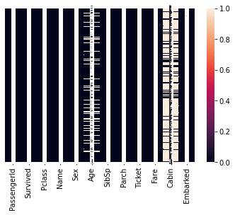

```python
#On Train Set
sns.heatmap(train_set.isnull(),yticklabels=False,annot=True)
```

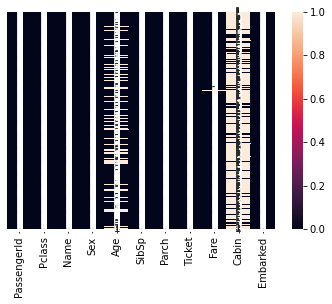

```python
#On the test set
sns.heatmap(test_set.isnull(),yticklabels=False,annot=True)
```

```python
# Summary statistics for training set
train_set.describe()
```

|  | PassengerId | Survived | Pclass | Age | SibSp | Parch | Fare |
| --- | --- | --- | --- | --- | --- | --- | --- |
| count | 891.000000 | 891.000000 | 891.000000 | 714.000000 | 891.000000 | 891.000000 | 891.000000 |
| mean | 446.000000 | 0.383838 | 2.308642 | 29.699118 | 0.523008 | 0.381594 | 32.204208 |
| std | 257.353842 | 0.486592 | 0.836071 | 14.526497 | 1.102743 | 0.806057 | 49.693429 |
| min | 1.000000 | 0.000000 | 1.000000 | 0.420000 | 0.000000 | 0.000000 | 0.000000 |
| 25% | 223.500000 | 0.000000 | 2.000000 | 20.125000 | 0.000000 | 0.000000 | 7.910400 |
| 50% | 446.000000 | 0.000000 | 3.000000 | 28.000000 | 0.000000 | 0.000000 | 14.454200 |
| 75% | 668.500000 | 1.000000 | 3.000000 | 38.000000 | 1.000000 | 0.000000 | 31.000000 |
| max | 891.000000 | 1.000000 | 3.000000 | 80.000000 | 8.000000 | 6.000000 | 512.329200 |

```python
# Summary statistics for test set
test_set.describe()
```

|  | PassengerId | Pclass | Age | SibSp | Parch | Fare |
| --- | --- | --- | --- | --- | --- | --- |
| count | 418.000000 | 418.000000 | 332.000000 | 418.000000 | 418.000000 | 417.000000 |
| mean | 1100.500000 | 2.265550 | 30.272590 | 0.447368 | 0.392344 | 35.627188 |
| std | 120.810458 | 0.841838 | 14.181209 | 0.896760 | 0.981429 | 55.907576 |
| min | 892.000000 | 1.000000 | 0.170000 | 0.000000 | 0.000000 | 0.000000 |
| 25% | 996.250000 | 1.000000 | 21.000000 | 0.000000 | 0.000000 | 7.895800 |
| 50% | 1100.500000 | 3.000000 | 27.000000 | 0.000000 | 0.000000 | 14.454200 |
| 75% | 1204.750000 | 3.000000 | 39.000000 | 1.000000 | 0.000000 | 31.500000 |
| max | 1309.000000 | 3.000000 | 76.000000 | 8.000000 | 9.000000 | 512.329200 |

## b) Feature analysis

A dataframe is made up of rows and columns. Number of rows correspond to the number of observations in our dataset whereas columns, sometimes called features, represent characteristics that help describe these observations. In our dataset:

i) Rows are the passengers on the titanic

ii)Columns are the features that describe the passengers like their age, gender etc.

Its important note the difference between a categorical variable and a numerical variable.

#### I)Categorical variables

As the name suggests, have values belonging to one of two or more categories and there is usually no intrinsic ordering to these categories eg the Sex feature. Every passenger is distinctly classified as either male or female.

#### ii)Numerical variables

Numerical variables have a continuous distribution eg Age and Fare features.

Knowing if a feature is a numerical variable or categorical variable helps us structure our analysis more properly.The better the quality of the data, the more accurate our resuts will be.

Now let try to analyse the features in our dataset individually and see how they correlate with survival probability.

### 4 b) i) Categorical variables

```python
# A quick way to separate numeric  and categorical values separately
train_set.describe().columns
```

```
Index(['PassengerId', 'Survived', 'Pclass', 'Age', 'SibSp', 'Parch', 'Fare'], dtype='object')
```

```python
#Finding numerical and categorical data column names
num_df = [ i for i in train_set.columns if train_set.dtypes[i]!='object' ] # histograms
cat_df = [ i for i in train_set.columns if train_set.dtypes[i]=='object' ] # value counts
```

```python
#categorigal data
cat_df
```

```
['Name', 'Sex', 'Ticket', 'Cabin', 'Embarked']
```

```python
# Get a count on the number of survivors
train_set['Survived'].value_counts()
```

```
0    549
1    342
Name: Survived, dtype: int64
```

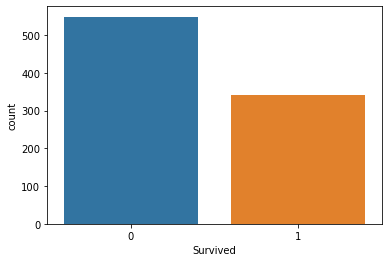

```python
#Visualize the count of survivors
sns.countplot(train_set['Survived'])
```

## Categorical variable: Pclass

```python
#Value Counts of the Pclass Column

train_set['Pclass'].value_counts(dropna = False)
```

```
3    491
1    216
2    184
Name: Pclass, dtype: int64
```

```python
#Showing the reationship between Survival columns and pclass column
train_set[['Survived', 'Pclass']].groupby(['Pclass'], as_index=False).mean()
```

|  | Pclass | Survived |
| --- | --- | --- |
| 0 | 1 | 0.629630 |
| 1 | 2 | 0.472826 |
| 2 | 3 | 0.242363 |

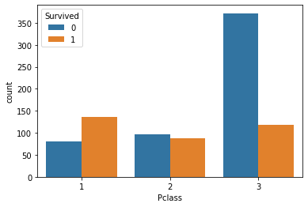

```python
sns.countplot(x=train_set['Pclass'], hue=train_set['Survived'])
```

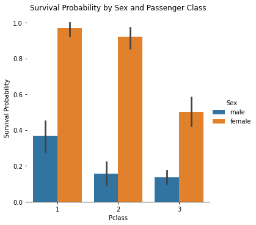

```python
# Survival by gender and p class.The below Shows women had a higher survival rate than men

g = sns.factorplot(x = 'Pclass', y = 'Survived', hue = 'Sex', data = train_set, kind = 'bar')
g.despine(left = True)
plt.ylabel('Survival Probability')
plt.title('Survival Probability by Sex and Passenger Class')
```

## Categorical variable: SEX

```python
#Value counts of the Sex Column
train_set['Sex'].value_counts(dropna = False)
```

```
male      577
female    314
Name: Sex, dtype: int64
```

```python
train_set[['Sex', 'Survived']].groupby(['Sex'], as_index=False).mean()
```

|  | Sex | Survived |
| --- | --- | --- |
| 0 | female | 0.742038 |
| 1 | male | 0.188908 |

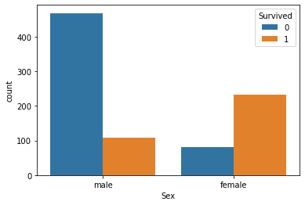

```python
sns.countplot(x=train_set['Sex'], hue=train_set['Survived'])
```

## Categorical variable: Embarked

```python
#Value Counts of the Embarked Column
train_set['Embarked'].value_counts(dropna = False)
```

```
S      644
C      168
Q       77
NaN      2
Name: Embarked, dtype: int64
```

```python
train_set[['Embarked', 'Survived']].groupby(['Embarked'], as_index=False).mean()
```

|  | Embarked | Survived |
| --- | --- | --- |
| 0 | C | 0.553571 |
| 1 | Q | 0.389610 |
| 2 | S | 0.336957 |

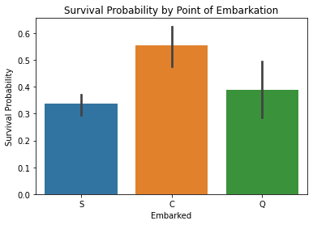

```python
sns.barplot(x = 'Embarked', y ='Survived', data = train_set)
plt.ylabel('Survival Probability')
plt.title('Survival Probability by Point of Embarkation')
```

From the above gragh, we can see the highest probability survival was on location c and the lowest on location s

Below we try to look a relationship between the pclass and the loaction on embarked for more insights on the survival probabillty.

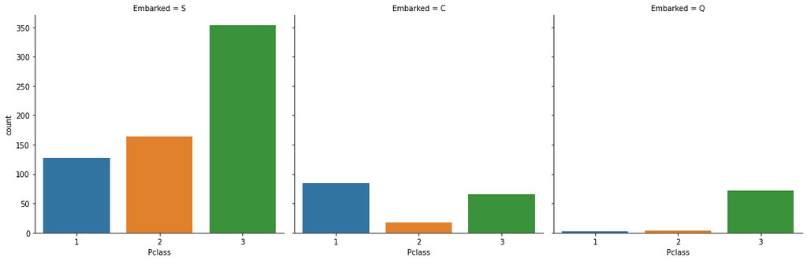

```python
sns.factorplot('Pclass', col = 'Embarked', data = train_set, kind = 'count')
```

There could have been more third class passengers that embarked from location S and because they have the lowest survival probability, this has caused location S to have the lowest survival probability.

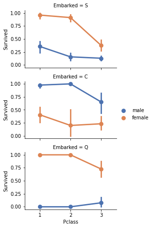

```python
# Survival probability by all categorical variables
grid = sns.FacetGrid(train_set, row = 'Embarked', size = 2.2, aspect = 1.6)
grid.map(sns.pointplot, 'Pclass', 'Survived', 'Sex', palette = 'deep')
grid.add_legend()
```

## 4 b) ii) Numerical variables

```python
num_df
```

```
['PassengerId', 'Survived', 'Pclass', 'Age', 'SibSp', 'Parch', 'Fare']
```

## Detect and remove outliers in numerical variables

Outliers are data points that have extreme values and they do not conform with the majority of the data. It is important to address this because outliers tend to skew our data towards extremes and can cause inaccurate model predictions. I will use the Tukey method to remove these outliers.

```python
# Outlier detection

import collections
from collections import Counter

def detect_outliers(df,n,features):
    """
    Takes a dataframe df of features and returns a list of the indices
    corresponding to the observations containing more than n outliers according
    to the Tukey method.
    """
    outlier_indices = []

    # iterate over features(columns)
    for col in features:
        # 1st quartile (25%)
        Q1 = np.percentile(df[col], 25)
        # 3rd quartile (75%)
        Q3 = np.percentile(df[col],75)
        # Interquartile range (IQR)
        IQR = Q3 - Q1

        # outlier step
        outlier_step = 1.5 * IQR

        # Determine a list of indices of outliers for feature col
        outlier_list_col = df[(df[col] < Q1 - outlier_step) | (df[col] > Q3 + outlier_step )].index

        # append the found outlier indices for col to the list of outlier indices
        outlier_indices.extend(outlier_list_col)

    # select observations containing more than 2 outliers
    outlier_indices = Counter(outlier_indices)
    multiple_outliers = list( k for k, v in outlier_indices.items() if v > n )

    return multiple_outliers

# detect outliers from Age, SibSp , Parch and Fare
Outliers_to_drop = detect_outliers(train_set,2,["Age","SibSp","Parch","Fare"])
```

Since outliers can have a dramatic effect on the prediction (espacially for regression problems), i choosed to manage them.

I used the Tukey method (Tukey JW., 1977) to detect ouliers which defines an interquartile range comprised between the 1st and 3rd quartile of the distribution values (IQR). An outlier is a row that have a feature value outside the (IQR +- an outlier step).

```python
# Show the outliers rows
train_set.loc[Outliers_to_drop]
```

|  | PassengerId | Survived | Pclass | Name | Sex | Age | SibSp | Parch | Ticket | Fare | Cabin | Embarked |
| --- | --- | --- | --- | --- | --- | --- | --- | --- | --- | --- | --- | --- |
| 27 | 28 | 0 | 1 | Fortune, Mr. Charles Alexander | male | 19.0 | 3 | 2 | 19950 | 263.00 | C23 C25 C27 | S |
| 88 | 89 | 1 | 1 | Fortune, Miss. Mabel Helen | female | 23.0 | 3 | 2 | 19950 | 263.00 | C23 C25 C27 | S |
| 159 | 160 | 0 | 3 | Sage, Master. Thomas Henry | male | NaN | 8 | 2 | CA. 2343 | 69.55 | NaN | S |
| 180 | 181 | 0 | 3 | Sage, Miss. Constance Gladys | female | NaN | 8 | 2 | CA. 2343 | 69.55 | NaN | S |
| 201 | 202 | 0 | 3 | Sage, Mr. Frederick | male | NaN | 8 | 2 | CA. 2343 | 69.55 | NaN | S |
| 324 | 325 | 0 | 3 | Sage, Mr. George John Jr | male | NaN | 8 | 2 | CA. 2343 | 69.55 | NaN | S |
| 341 | 342 | 1 | 1 | Fortune, Miss. Alice Elizabeth | female | 24.0 | 3 | 2 | 19950 | 263.00 | C23 C25 C27 | S |
| 792 | 793 | 0 | 3 | Sage, Miss. Stella Anna | female | NaN | 8 | 2 | CA. 2343 | 69.55 | NaN | S |
| 846 | 847 | 0 | 3 | Sage, Mr. Douglas Bullen | male | NaN | 8 | 2 | CA. 2343 | 69.55 | NaN | S |
| 863 | 864 | 0 | 3 | Sage, Miss. Dorothy Edith "Dolly" | female | NaN | 8 | 2 | CA. 2343 | 69.55 | NaN | S |

### Notes to take from the above summary:

a)We detect 10 outliers. The 27, 88 and 341 passengers have an high Ticket Fare

b)The 7 others have very high values of SibSP.

```python
# Drop outliers
print("Before: {} rows".format(len(train_set)))
train_set = train_set.drop(Outliers_to_drop, axis = 0).reset_index(drop=True)
print("After: {} rows".format(len(train_set)))
```

```
Before: 891 rows
After: 881 rows
```

```python
print("After: {} rows".format(len(train_set)))
```

```
After: 881 rows
```

### Numerical variables correlation with survival

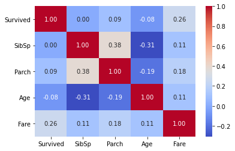

```python
sns.heatmap(train_set[['Survived', 'SibSp', 'Parch', 'Age', 'Fare']].corr(), annot = True, fmt = '.2f', cmap = 'coolwarm')
```

Note that Fare seems to be the only feature that has a substantial correlation with survival

## Numerical variables: Parch

```python
#Value Counts of the Parch Column
train_set['Parch'].value_counts(dropna = False)
```

```
0    678
1    118
2     70
5      5
3      5
4      4
6      1
Name: Parch, dtype: int64
```

```python
# Mean of survival by Parch
train_set[['Parch', 'Survived']].groupby(['Parch'], as_index=False).mean()
```

|  | Parch | Survived |
| --- | --- | --- |
| 0 | 0 | 0.343658 |
| 1 | 1 | 0.550847 |
| 2 | 2 | 0.542857 |
| 3 | 3 | 0.600000 |
| 4 | 4 | 0.000000 |
| 5 | 5 | 0.200000 |
| 6 | 6 | 0.000000 |

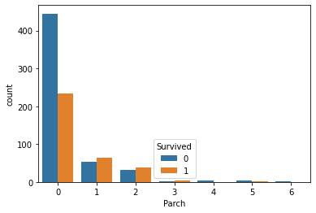

```python
sns.countplot(x=train_set['Parch'], hue=train_set['Survived'])
```

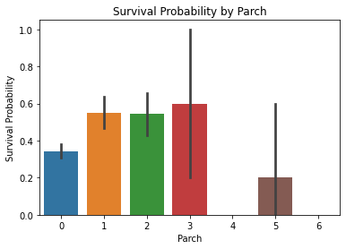

```python
sns.barplot(x = 'Parch', y ='Survived', data = train_set)
plt.ylabel('Survival Probability')
plt.title('Survival Probability by Parch')
```